Political commentary · News analysis · Investigative opinion journalism

The Conservative record · Analysis & opinion

# KEMI’S GANG DID THIS

Fourteen years. Five prime ministers.  
A record the Conservatives cannot escape.

By Steve English · 18 October 2026 · Read the sources

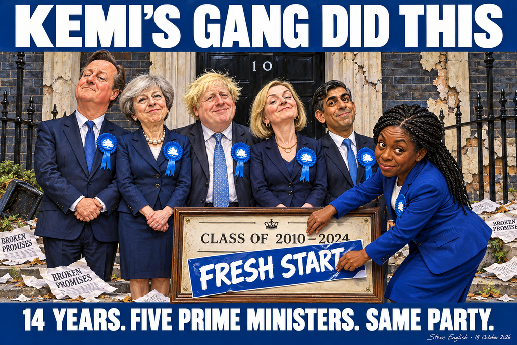

Political satire: 14 years. Five prime ministers. Same party.

The Conservatives would like another hearing.

On immigration, taxation, policing and public services, they want voters to believe they have the answers.

Before considering another set of promises, we should examine what happened when they had the power to deliver.

From May 2010 to July 2024, Britain had Conservative-led governments. The party supplied five successive prime ministers: David Cameron, Theresa May, Boris Johnson, Liz Truss and Rishi Sunak.

Different leaders made different decisions. But changing the person outside Downing Street did not change the party responsible.

## They promised immigration control.

In 2010, the incoming government explicitly promised to reduce annual net migration to the “tens of thousands”.

That promise is still available on the government’s own website. It was a commitment they chose to make to the British public. [1]

Compare it with what followed.

In November 2025, the Office for National Statistics published revised estimates putting net migration at **944,000 in the year ending March 2023.**

That is net migration: the difference between long-term arrivals and departures. It is not a count of small-boat crossings or asylum applications. [2]

A party that promised tens of thousands presided over an estimated annual figure approaching a million.

Voters are entitled to judge that enormous gap between the promise and the outcome.

## They promised low taxes.

There were tax cuts during those fourteen years. The personal allowance increased substantially, and National Insurance cuts benefited workers towards the end of their time in office.

But the same governments raised VAT from 17.5% to 20%, increased the main corporation tax rate from 19% to 25% in 2023, and froze personal income tax thresholds. [3]

A frozen threshold sounds harmless until wages rise and more of your income becomes taxable. You can pay more tax without becoming better off in real terms.

That is why the headline income tax rate tells only part of the story.

In its June 2024 assessment, the Institute for Fiscal Studies said the outgoing parliament was on course for the largest increase in the tax take, as a share of national income, of any parliament on record. That assessment used the forecasts available before the election. [3]

The party’s low-tax reputation deserves to be measured against its own decisions.

## They promised to be tough on crime.

Police recruitment became a major Conservative selling point.

But recruitment followed years of falling numbers under Conservative-led governments. Home Office figures show the workforce shrinking after 2010 and subsequently recovering. By March 2024, officer numbers in England and Wales had reached a record level. [4]

The recovery should be acknowledged. So should the preceding cuts.

Voters experienced both halves of that story: the reduction in policing resources, followed by a government celebrating their restoration.

A recruitment announcement does not erase the years that came before it.

## They promised prison places.

Here, the difference between what was built and what remained available matters.

According to the Ministry of Justice’s published calculation, total operational prison capacity in England and Wales rose from **89,757 in May 2010 to 90,239 in April 2024.**

> A net increase of 482 places.

That does not mean only 482 places were built. New accommodation was added while other accommodation was lost. The figure measures the overall change in operational capacity. [5]

After almost fourteen years, the net gain on that measure was fewer than 500 places.

And emergency early release began before Labour returned to government. The Conservative government introduced the End of Custody Supervised Licence scheme in October 2023, initially allowing eligible prisoners to leave up to 18 days early. It was subsequently expanded. [6]

That belongs in any honest account of the inheritance they left.

## They promised to protect the NHS.

NHS England’s June 2024 operational update reported **7.6 million outstanding waits** for procedures and appointments at the end of April, involving an estimated **6.3 million people.**

The distinction matters: one person can be waiting for more than one treatment. [7]

Those figures describe millions of people living with uncertainty, discomfort or pain.

The pandemic placed extraordinary pressure on healthcare. Any fair assessment must recognise that.

But a government’s responsibility includes preparing services for shocks and managing the recovery. Fourteen years in office carries responsibility for the condition in which those services are handed over.

## They promised economic competence.

Then came the turmoil of autumn 2022.

In the days following the Truss government’s mini-budget, the Bank of England intervened in the government bond market. Its announcement identified risks to financial stability and said urgent purchases were needed to restore orderly market conditions. [8]

The episode had several causes and vulnerabilities, including the structure of some pension funds. It cannot explain every subsequent movement in mortgage rates or borrowing costs.

But it remains part of the Conservative record. Their claim to economic competence must withstand examination of their time in government.

## Now they want another chance.

Labour must answer for Labour’s decisions. Every failure of the present government deserves scrutiny.

The Conservatives must answer for theirs.

They cannot reasonably ask voters to remember their promises while forgetting their decisions. They cannot claim credit for rebuilding services without acknowledging the cuts that preceded it. And they cannot present every inherited crisis as though they had no involvement in creating it.

Before asking the country to trust them again, they owe it a clear account of what went wrong, who made the decisions and why the next result would be different.

Until then, beneath the next Conservative promise, voters would be justified in writing:

KEMI’S GANG DID THIS.

## Want to dive deeper? Read the sources.

Direct links to the government publications, official statistics and independent analysis used above.

1. [The immigration promise — GOV.UK, June 2010](https://www.gov.uk/government/news/uk-government-commits-to-impose-migration-limit)
2. [Revised migration estimates — Office for National Statistics, November 2025](https://blog.ons.gov.uk/2025/11/18/updating-our-methods-to-improve-eu-and-british-migration-statistics/)
3. [The government’s record on tax, 2010–24 — Institute for Fiscal Studies](https://ifs.org.uk/publications/governments-record-tax-2010-24)
4. [Police workforce, England and Wales, March 2024 — Home Office](https://www.gov.uk/government/statistics/police-workforce-england-and-wales-31-march-2024/police-workforce-england-and-wales-31-march-2024)
5. [Prison places built and closed, 2010–2024 — Ministry of Justice](https://www.gov.uk/government/publications/the-number-of-prison-places-built-and-closed-2010-2024)
6. [Offender management statistics, October–December 2023 — Ministry of Justice](https://www.gov.uk/government/statistics/offender-management-statistics-quarterly-october-to-december-2023/offender-management-statistics-quarterly-october-to-december-2023-and-annual-2023)
7. [Monthly operational statistics, June 2024 — NHS England](https://www.england.nhs.uk/long-read/monthly-operational-statistics-june-2024/)
8. [Gilt-market intervention, September 2022 — Bank of England](https://www.bankofengland.co.uk/news/2022/september/bank-of-england-announces-gilt-market-operation)

## Let the British Lions Roar come to you.

Get our articles free to your inbox. Subscribe on Substack and share the stories you want others to read.

[Subscribe free on Substack](https://thebritishlionsroar.substack.com/)

[figure not shown]

On your phone? Tap the button. On another screen? Scan the code.

Editorial approach: Plain English, sourced facts and clearly expressed opinion. This article examines the record of Conservative-led UK governments between 2010 and 2024. Police and prison figures cited cover England and Wales; NHS figures cover England. Statistical estimates may be revised.

**DISCLAIMER**  
This is political commentary and opinion supported by the linked sources. The illustration is satire. Nothing here encourages violence, harassment or hatred.